# Lab-7

Alex Steiner

2024-03-06

### 1. Think about an ongoing study in your lab (or a paper you have read in a different class), and decide on a pattern that you might expect in your experiment if a specific hypothesis were true.

I would expect soil organic matter to be greater in pastures that are practicing management intensive rotational grazing (MIRG) when compared with continuously grazed pastures.

### 2. To start simply, assume that the data in each of your treatment groups follow a normal distribution. Specify the sample sizes, means, and variances for each group that would be reasonable if your hypothesis were true. You may need to consult some previous literature and/or an expert in the field to come up with these numbers.

```r
library(ggplot2)
library(tidyverse)
library(rstatix)
```

Importing data for estimates.

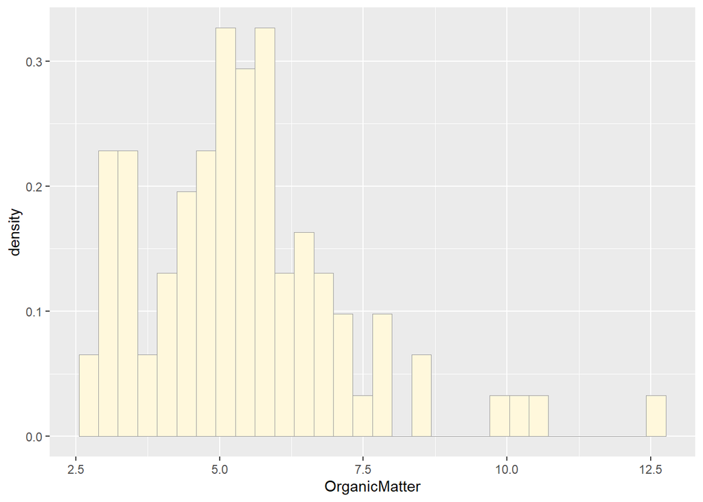

```r
om <- read.csv("om-dummy.csv")

#converting to factor variables
om$Practice <- as.factor(om$Practice)

##Looking at data (not too normal looking but we will assume it is.)
ggplot(data=om, aes(x=OrganicMatter, y=after_stat(density))) +
  geom_histogram(color="grey60",fill="cornsilk",size=0.2)
```

```r
#summary stats
om %>%
  group_by(Practice) %>%
  get_summary_stats(OrganicMatter, type = "mean_sd")
```

```
## # A tibble: 3 × 5
##   Practice        variable          n  mean    sd
##   <fct>           <fct>         <dbl> <dbl> <dbl>
## 1 MIRG            OrganicMatter    30  6.33 2.11
## 2 NegativeControl OrganicMatter    30  4.10 1.28
## 3 PositiveControl OrganicMatter    30  5.83 0.919
```

Practice Mean SD MIRG-experimental 6.334 2.111 Continuous 4.104 1.282 MIRG-Control 5.834 0.919

### 3. Using the methods we have covered in class, write code to create a random data set that has these attributes. Organize these data into a data frame with the appropriate structure.

```r
# Anova
nGroup <- 3 # number of treatment groups
nName <- c("MirgExp","MirgCtrl", "Continuous") # names of groups
nSize <- c(30,30,30) # number of observations in each group
nMean <- c(6.334,5.834,4.104) # mean of each group
nSD <- c(2.111,0.919,1.282) # standardd deviation of each group

ID <- 1:(sum(nSize)) # id vector for each row
resVar <- c(rnorm(n=nSize[1],mean=nMean[1],sd=nSD[1]),
            rnorm(n=nSize[2],mean=nMean[2],sd=nSD[2]),
            rnorm(n=nSize[3],mean=nMean[3],sd=nSD[3]))
TGroup <- rep(nName,nSize)
ANOdata <- data.frame(ID,TGroup,resVar)
```

### 4. Now write code to analyze the data (probably as an ANOVA or regression analysis, but possibly as a logistic regression or contingency table analysis. Write code to generate a useful graph of the data.

```r
##anova in r

ANOmodel <- aov(resVar~TGroup,data=ANOdata)
z <- summary(ANOmodel)
print(z)
```

```
##             Df Sum Sq Mean Sq F value   Pr(>F)
## TGroup       2  110.4   55.19   39.68 5.66e-13 ***
## Residuals   87  121.0    1.39
## ---
## Signif. codes:  0 '***' 0.001 '**' 0.01 '*' 0.05 '.' 0.1 ' ' 1
```

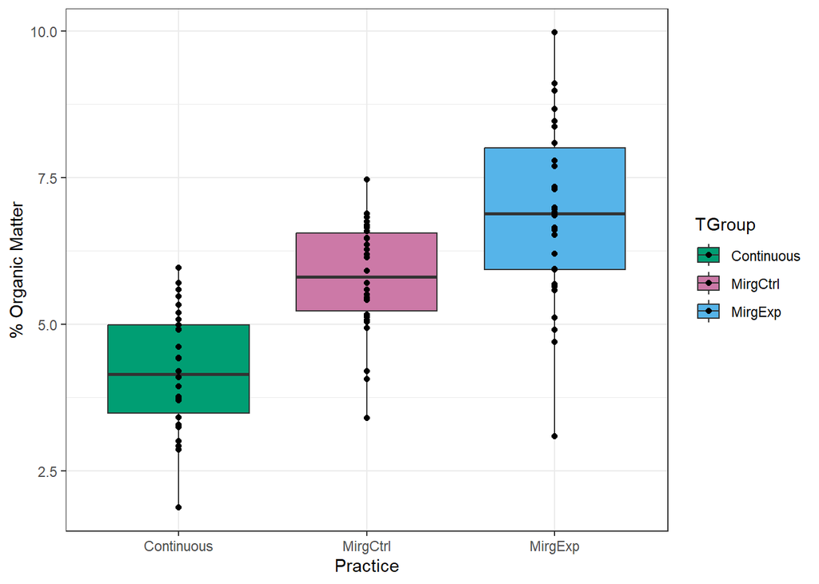

```r
##ggplot
cbPalette <- c("#009E73","#CC79A7","#56B4E9")

ANOPlot <- ggplot(data=ANOdata) +
  aes(x=TGroup,y=resVar,fill=TGroup) +
  geom_boxplot()+
  scale_fill_manual(values=cbPalette)+
  labs(y = "% Organic Matter", x = "Practice")+
  geom_point()+
  theme_bw()


print(ANOPlot)
```

### 5. Try running your analysis multiple times to get a feeling for how variable the results are with the same parameters, but different sets of random numbers.

Re-ran above code without setting seed.

### 6. Now begin adjusting the means of the different groups. Given the sample sizes you have chosen, how small can the differences between the groups be (the “effect size”) for you to still detect a significant pattern (p < 0.05)?

```r
set.seed(1137)

nGroup <- 3 # number of treatment groups
nName <- c("MirgExp","MirgCtrl", "Continuous") # names of groups
nSize <- c(30,30,30) # number of observations in each group
nMean <- c(5.9,5.834,5.17) # mean of each group
nSD <- c(2.111,0.919,1.282) # standardd deviation of each group

ID <- 1:(sum(nSize)) # id vector for each row
resVar <- c(rnorm(n=nSize[1],mean=nMean[1],sd=nSD[1]),
            rnorm(n=nSize[2],mean=nMean[2],sd=nSD[2]),
            rnorm(n=nSize[3],mean=nMean[3],sd=nSD[3]))
TGroup <- rep(nName,nSize)
ANOdata <- data.frame(ID,TGroup,resVar)

ANOmodel <- aov(resVar~TGroup,data=ANOdata)
z <- summary(ANOmodel)
print(z)
```

```
##             Df Sum Sq Mean Sq F value Pr(>F)
## TGroup       2  13.42   6.712   3.086 0.0507 .
## Residuals   87 189.22   2.175
## ---
## Signif. codes:  0 '***' 0.001 '**' 0.01 '*' 0.05 '.' 0.1 ' ' 1
```

```r
## I had to change the Continuous from 4.1 to 5.17. Quite a big change!
```

### 7. Alternatively, for the effect sizes you originally hypothesized, what is the minimum sample size you would need in order to detect a statistically significant effect? Again, run the model a few times with the same parameter set to get a feeling for the effect of random variation in the data.

```r
nGroup <- 3 # number of treatment groups
nName <- c("MirgExp","MirgCtrl", "Continuous") # names of groups
nSize <- c(4,4,4) # number of observations in each group
nMean <- c(6.334,5.834,4.104) # mean of each group
nSD <- c(2.111,0.919,1.282) # standardd deviation of each group

ID <- 1:(sum(nSize)) # id vector for each row
resVar <- c(rnorm(n=nSize[1],mean=nMean[1],sd=nSD[1]),
            rnorm(n=nSize[2],mean=nMean[2],sd=nSD[2]),
            rnorm(n=nSize[3],mean=nMean[3],sd=nSD[3]))
TGroup <- rep(nName,nSize)
ANOdata <- data.frame(ID,TGroup,resVar)


ANOmodel <- aov(resVar~TGroup,data=ANOdata)
z <- summary(ANOmodel)
print(z)
```

```
##             Df Sum Sq Mean Sq F value Pr(>F)
## TGroup       2   4.59   2.295   0.611  0.564
## Residuals    9  33.84   3.760
```

This was very surprising! I had to lower the sample sizes to 4 before it became non-significant at the 0.05 level.